# Analysis of Climate Change

Anthony Koukoullis  
14/01/2017

### Introduction

- Analysis of the current research in climate change.
- Investigation of the factors involved in the causes and the corresponding planet-wide atmospheric, agricultural, and oceanic effects.
- Findings that the theory of man-caused climate change is indeed a probable phenomenon based on the data collected worldwide.
- This presentation will explore data which strongly suggests that the climate change hypothesis is true.

### Causes of Climate Change

- General consensus amongst climate scientists is that the main cause of the current global warming trend is human expansion of the “greenhouse effect”.
- The greenhouse effect itself is a natural phenomenon which is the trapping of solar heat in the atmosphere using atmospheric gases.
- Water vapour, Carbon dioxide, Methane, Nitrous oxide, and Halogenated gases in the atmosphere block heat from escaping.

### Causes of Climate Change

- Over the last century, increase in burning of fossil fuels such as coal and oil has pumped more carbon into the atmosphere.
- The carbon, which bonds with atmospheric oxygen, produces carbon dioxide, and has increased the concentration of atmospheric CO<sub>2</sub>.

### Causes of Climate Change

## Greenhouse Gases

- Carbon dioxide (CO<sub>2</sub>) allows incoming solar radiation from the sun to pass through it and warm the earth's surface. The earth's surface reflects portion of this energy upwards as thermal radiation, which is absorbed and re-radiated by the atmosphere's CO<sub>2</sub> molecules back toward earth's surface.
- Humans have increased CO<sub>2</sub> release through deforestation, land use changes, and burning of fossil fuels.
- 87 percent of all human-produced carbon dioxide emissions come from the burning of fossil fuels like coal, natural gas and oil. The remainder results from the clearing of forests and other land use changes (9%), as well as some industrial processes such as cement manufacturing (4%).

### Causes of Climate Change

## Greenhouse Gases

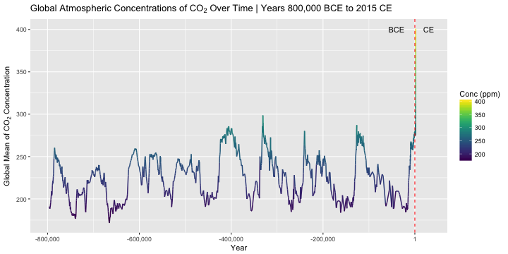

### Causes of Climate Change

## Deforestation

- Deforestation in tropical rainforests adds more carbon dioxide to the atmosphere than the sum total of cars and trucks on the world’s roads.
- Trees convert CO<sub>2</sub> in the air to oxygen, through photosynthesis, so are a natural regulator of CO<sub>2</sub>.
- According to the plot on the next slide, from 1990 to 2015 approximately 1,384,593 km<sup>2</sup> of rainforest has been cleared.

### Causes of Climate Change

## Deforestation

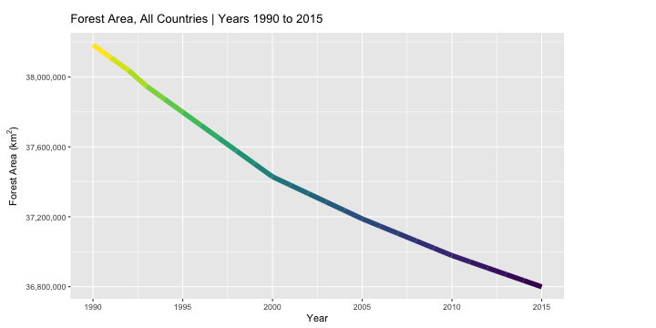

### Causes of Climate Change

## Deforestation

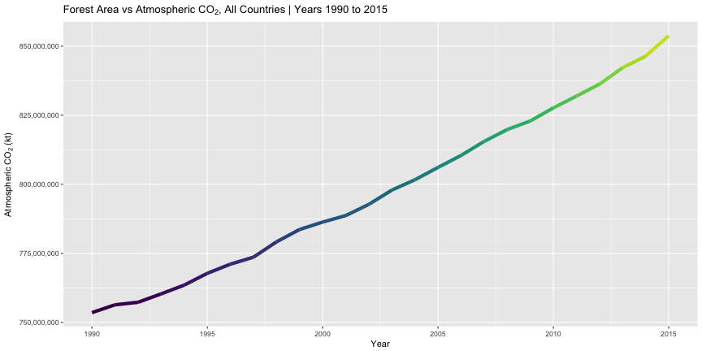

### Causes of Climate Change

## Deforestation

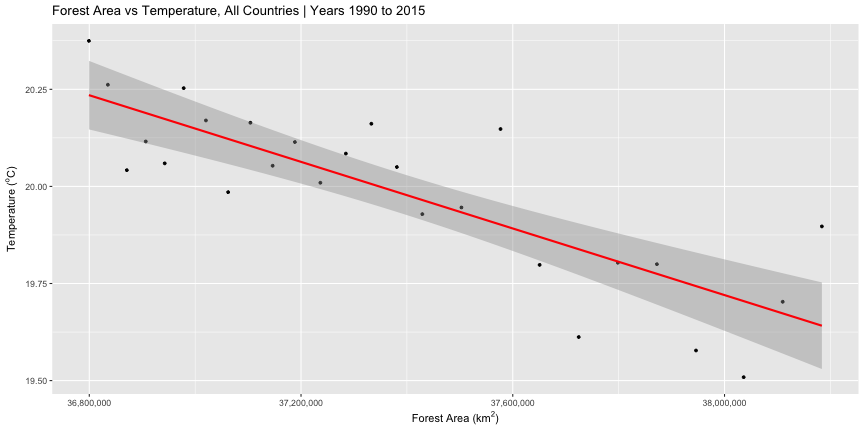

### Causes of Climate Change

## GDP

- The Gross Domestic Product, or GDP, is a monetary measure of the market value of all final goods and services produced in a period.
- The cause of a rise in a nation's GDP is the increase in the production of good and services, which includes industrial process and outputs.
- This industrial output, combined with consumer activities, generate climate-changing CO<sub>2</sub> emissions.

### Causes of Climate Change

## GDP

- The *GDP* vs *Atmospheric CO<sub>2</sub>* shows a strong visual correlation between these two variables, as an increase in *GDP* correlates with an increase in *Atmospheric CO<sub>2</sub>*.
- The Pearson correlation estimate is 0.96, with a p-value of 2.64e-14, which validates the strong correlation shown in the plot.

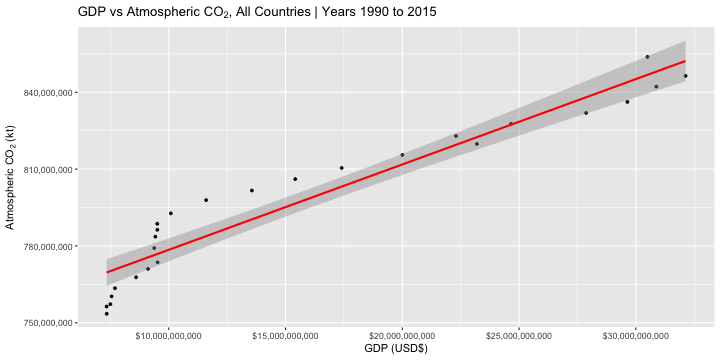

### Effects of Climate Change

## Atmospheric Temperature

- The core variable at the heart of the study of climate change is the planet's atmospheric temperature.
- The primary effect of the increase in greenhouse gases in the atmosphere is the the increase in average atmospheric temperatures.
- The plot below shows an overall increase in worldwide temperatures from the year 1990 to 2015.

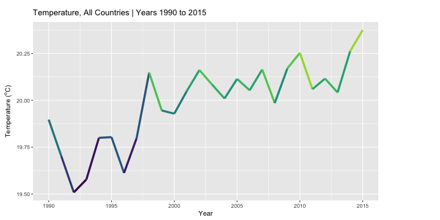

### Effects of Climate Change

## Global Mean Sea Level

- As the oceans warm due to an increasing global temperature, seawater expands, taking up more space in the ocean basin and causing a rise in water level.
- Secondly, the melting of ice over land, such as in Greenland or Antarctica, adds water to the ocean.

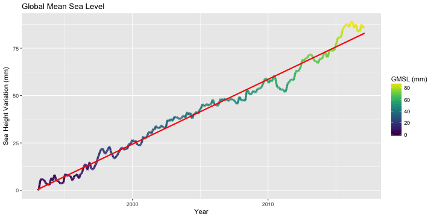

### Effects of Climate Change

## Land Ice Mass

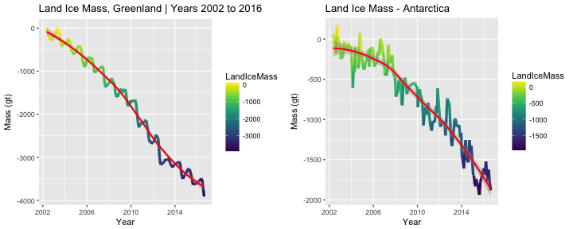

### Effects of Climate Change

## Global Food Production

- Effects of climate change on global food production are simulated for a future outcome using models.
- The projection model used is the IPCC (Intergovernmental Panel on Climate Change) Special Report on Emissions Scenarios, or SRES for short.
- The SRES A1FI Scenario describes a future world of very rapid economic growth, global population that peaks in mid-century and declines thereafter, and the rapid introduction of new and more efficient technologies.

### Effects of Climate Change

## Global Food Production

- Countries that will have a negative change in wheat yield production are Central American countries such as Mexico, Scandinavian countries such as Norway, Denmark, Sweden, European countries such as Poland and Austria, and Eastern Bloc countries such as Belarus.

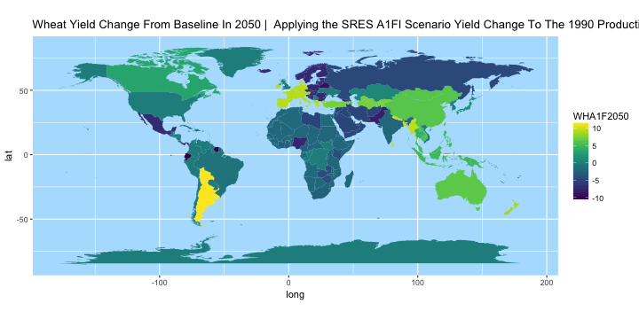

### Effects of Climate Change

## Global Food Production

- Scandinavian countries, Middle Eastern countries, the Russian Federation, and most of Africa except for the Democratic Republic of Congo and the Central African Republic will suffer decreased maize yield production.

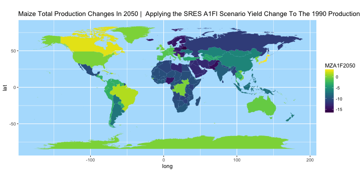